# Import

You goal is to download daily low/high temperature for Auckland between 1 January 1980 and 30 June 2023. Visit the historical API decription page: https://open-meteo.com/en/docs/historical-weather-api and construct a URL that includes the desired data. You will need to set the parameters latitude, longitude, daily, timezone, start_date and end_date. You should use the time zone “Pacific/Auckland”.

1 Use the curl command in unix to download the result into the file akl.json. (Hint: look at the resulting file to ensure correctness of your request; the & character has a special meaning in the shell and must be escaped).

```bash
curl -o akl.json "https://archive-api.open-meteo.com/v1/archive?latitude=-36.8485&longitude=174.7633&start_date=1980-01-01&end_date=2023-06-30&daily=temperature_2m_max,temperature_2m_min&timezone=Pacific%2FAuckland"
```

```
##   % Total    % Received % Xferd  Average Speed   Time    Time     Time  Current
##                                  Dload  Upload   Total   Spent    Left  Speed
##
  0     0    0     0    0     0      0      0 --:--:-- --:--:-- --:--:--     0
  0     0    0     0    0     0      0      0 --:--:-- --:--:-- --:--:--     0
100 16189    0 16189    0     0  12777      0 --:--:--  0:00:01 --:--:-- 12777
100  207k    0  207k    0     0  97158      0 --:--:--  0:00:02 --:--:-- 97158
100  354k    0  354k    0     0   160k      0 --:--:--  0:00:02 --:--:--  160k
```

2 Read the result into an R object jd. It should have similar structure like this (NOTE: this is NOT the correct data, your values will be different, it just shows the result structure):

str(jd) List of 9 $ latitude : num -46.5 $ longitude : num 168 $ generationtime_ms : num 864 $ utc_offset_seconds : int 43200 $ timezone : chr “Pacific/Auckland” $ timezone_abbreviation: chr “NZST” $ elevation : num 10 $ daily_units :List of 3 ..$ time : chr “iso8601” ..$ temperature_2m_max: chr “°C” ..$ temperature_2m_min: chr “°C” $ daily :List of 3 ..$ time : chr [1:12234] “1990-01-01” “1990-01-02” “1990-01-03” “1990-01-04” … ..$ temperature_2m_max: num [1:12234] 15 17.9 16.6 20.1 13.5 13 17.8 15.7 13.2 14.1 … ..$ temperature_2m_min: num [1:12234] 8.7 9.9 11.7 9.9 9.1 9.6 7.2 10.1 9.4 10.8 …

```r
library(jsonlite)

# extract json data
jd <- fromJSON("akl.json")
str(jd)
```

```
## List of 9
##  $ latitude             : num -36.7
##  $ longitude            : num 175
##  $ generationtime_ms    : num 6.47
##  $ utc_offset_seconds   : int 43200
##  $ timezone             : chr "Pacific/Auckland"
##  $ timezone_abbreviation: chr "NZST"
##  $ elevation            : num 36
##  $ daily_units          :List of 3
##   ..$ time              : chr "iso8601"
##   ..$ temperature_2m_max: chr "°C"
##   ..$ temperature_2m_min: chr "°C"
##  $ daily                :List of 3
##   ..$ time              : chr [1:15887] "1980-01-01" "1980-01-02" "1980-01-03" "1980-01-04" ...
##   ..$ temperature_2m_max: num [1:15887] 20.1 19.6 18.1 20.8 21.5 21 20.9 21.2 20.7 21.8 ...
##   ..$ temperature_2m_min: num [1:15887] 16 15.4 15 13.4 14.8 15.3 16.4 16.1 17.1 17.4 ...
```

# Data description

The data used in this project is from the OpenMeteo.com API and covers the daily minimum and maximum temperatures for Auckland, New Zealand, from January 1, 1980, to June 30, 2023.

In addition to Auckland’s data, we also collected the highest temperature data for the entire year of 2022 from the five cities with largest population in New Zealand.

The dataset is organized into three main columns: Date (in the format “YYYY-MM-DD” representing the date), Minimum Temperature, and Maximum Temperature. Both the minimum and maximum temperatures are measured in degrees Celsius. Through this data, we can analyze the fluctuations in temperature over time and observe the temperature differences among different cities.

# Clean

```r
d <- data.frame(
  day = as.Date(jd$daily$time),
  min = jd$daily$temperature_2m_min,
  max = jd$daily$temperature_2m_max
)
```

# Explore

4. Check if the data is complete. Verify the sanity of the data.

```r
# check for missing value
apply(d, 2, function(x) any(is.na(x)))
```

```
##   day   min   max
## FALSE FALSE FALSE
```

```r
# check for missing date
all(diff(d$day) == 1)
```

```
## [1] TRUE
```

```r
# check for abnormal temperature
range(d$min)
```

```
## [1]  3.5 23.4
```

```r
range(d$max)
```

```
## [1]  8.6 27.9
```

```r
# check for abnormal range
all(d$min <= d$max)
```

```
## [1] TRUE
```

```r
# The data is complete and sanitized
```

# Model

5. We want to focus on the evolution of yearly average temperatures over time. In order to do that, let us define a daily mean estimate by taking the average of the minimum and maximum each day. Then for each year compute the averge of those daily averages. It should look something like this:

   str(avg) ‘data.frame’: 44 obs. of 2 variables: $ year: int 1980 1981 1982 1983 1984 1985 1986 1987 1988 1989 … $ avg : num 14.6 15.2 14.5 14.4 15.1 …

```r
# add daily mean tmp
d$daily_mean <- (d$min + d$max) / 2

# add yearly mean tmp
d$year <- as.numeric(format(d$day, "%Y"))
avg_data <- aggregate(daily_mean ~ year, data = d, FUN = mean)

colnames(avg_data) <- c("year", "avg")

str(avg_data)
```

```
## 'data.frame':    44 obs. of  2 variables:
##  $ year: num  1980 1981 1982 1983 1984 ...
##  $ avg : num  14.9 15.5 14.9 14.8 15.4 ...
```

Use years 1980-2014 as training set and remaining data as a test set. Fit two models to the training data: a simple overall mean and a linear regression model with the year as a predictor variable. Print the models and compute RMSE for the test set. Plot all the data and predictions.

```r
# create training set and test set
train_data <- avg_data[avg_data$year <= 2014,]
test_data <- avg_data[avg_data$year > 2014,]

# fit model
mean_model <- mean(train_data$avg)
linear_model <- lm(avg ~ year, data = train_data)
mean_model
```

```
## [1] 15.33815
```

```r
linear_model
```

```
##
## Call:
## lm(formula = avg ~ year, data = train_data)
##
## Coefficients:
## (Intercept)         year
##   -12.45029      0.01392
```

```r
# prediction
mean_pred <- rep(mean_model, nrow(test_data))
linear_pred <- predict(linear_model, newdata = test_data)

# calculate RMSE
mean_rmse <- sqrt(mean((test_data$avg - mean_pred)^2))
linear_rmse <- sqrt(mean((test_data$avg - linear_pred)^2))
cat("Mean model RMSE:", mean_rmse)
```

```
## Mean model RMSE: 1.011665
```

```r
cat("\nLinear model RMSE:", linear_rmse)
```

```
##
## Linear model RMSE: 0.7370829
```

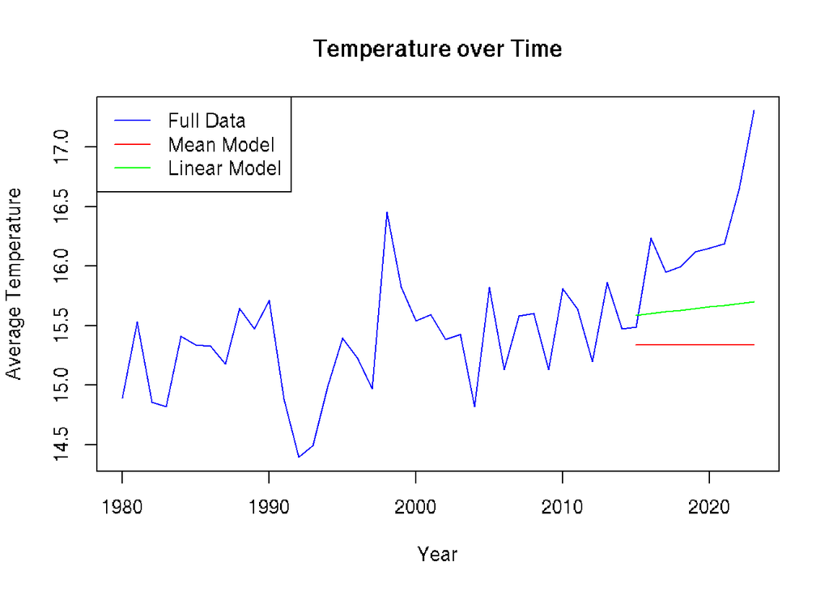

```r
test_data$mean_pred <- mean_pred
test_data$linear_pred <- linear_pred

# plot
# full data set
plot(avg_data$year, avg_data$avg, type = "l", col = "blue", xlab = "Year", ylab = "Average Temperature", main = "Temperature over Time", ylim = range(avg_data$avg))

# mean model red
lines(test_data$year, mean_pred, col = "red")

# linear model blue
lines(test_data$year, linear_pred, col = "green")

legend("topleft", legend = c("Full Data", "Mean Model", "Linear Model"),
       col = c("blue", "red", "green"), lty = 1)
```

Do you see a problem in the test set? Explain it (use R code to provide evidence for your hypothesis), propose a way to handle it, implement it using R and repeat the model validation. Comment on the suitability of the two models.

We can observe from the line plot that the data in the training set and the test set shows different trends. We can draw a scatter plot to identify.

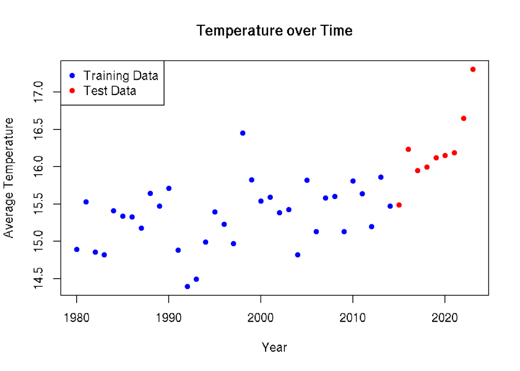

```r
# test and training set data distribution
plot(train_data$year, train_data$avg, pch = 16, col = "blue", xlab = "Year", ylab = "Average Temperature", main = "Temperature over Time", xlim = range(avg_data$year), ylim = range(avg_data$avg))

points(test_data$year, test_data$avg, pch = 16, col = "red")

legend("topleft", legend = c("Training Data", "Test Data"),
       col = c("blue", "red"), pch = c(16, 16))
```

The scatter plot is obvious that they show different trends(the test set shows a growing trend). The model fitting in this circumstance lead to bad prediction, and this may be the reason why our prediction shows a different pattern with the test set.

To handle this problem, we can fit a non-linear model to capture complicate trends.

```r
# polynomial model
polynomial_model <- lm(avg ~ poly(year, 2), data = train_data)
summary(polynomial_model)
```

```
##
## Call:
## lm(formula = avg ~ poly(year, 2), data = train_data)
##
## Residuals:
##      Min       1Q   Median       3Q      Max
## -0.87132 -0.31502  0.08827  0.25008  1.10196
##
## Coefficients:
##                Estimate Std. Error t value Pr(>|t|)
## (Intercept)    15.33815    0.06909 222.010   <2e-16 ***
## poly(year, 2)1  0.83142    0.40873   2.034   0.0503 .
## poly(year, 2)2  0.01710    0.40873   0.042   0.9669
## ---
## Signif. codes:  0 '***' 0.001 '**' 0.01 '*' 0.05 '.' 0.1 ' ' 1
##
## Residual standard error: 0.4087 on 32 degrees of freedom
## Multiple R-squared:  0.1145, Adjusted R-squared:  0.0592
## F-statistic:  2.07 on 2 and 32 DF,  p-value: 0.1428
```

```r
# prediction
polynomial_pred <- predict(polynomial_model, newdata = test_data)

# RMSE
polynomial_rmse <- sqrt(mean((test_data$avg - polynomial_pred)^2))
cat("Polynomial model RMSE:", polynomial_rmse)
```

```
## Polynomial model RMSE: 0.7255057
```

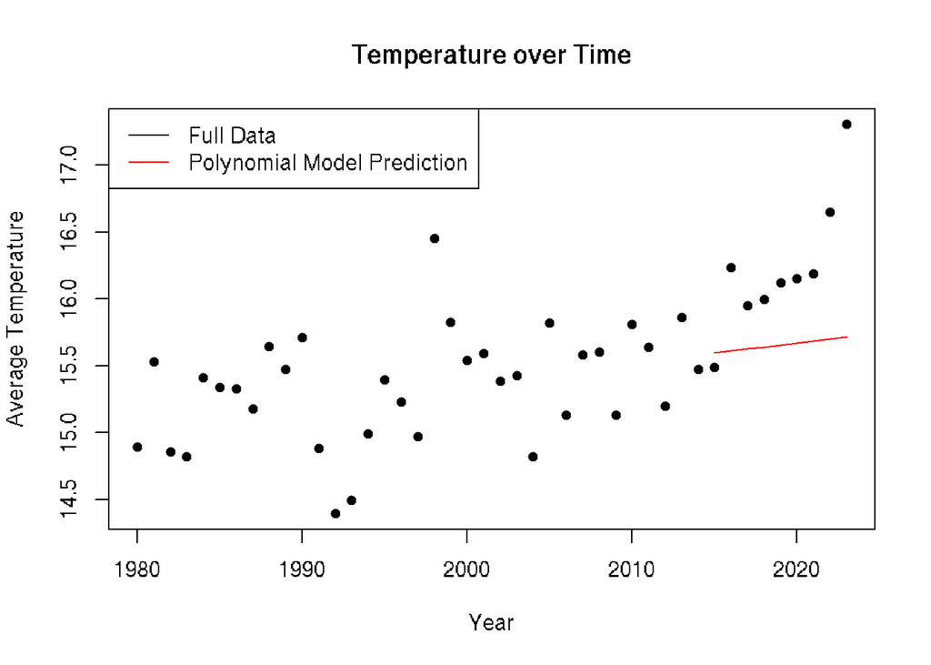

```r
# plot
plot(avg_data$year, avg_data$avg, pch = 16, col = "black", xlab = "Year", ylab = "Average Temperature", main = "Temperature over Time", ylim = range(avg_data$avg))

# polynomial model
lines(test_data$year, polynomial_pred, col = "red")

legend("topleft", legend = c("Full Data", "Polynomial Model Prediction"), col = c("black","red"), lty = 1)
```

Comment on the suitability of the two models: We compared the mean model and the linear regression model. The mean model is simpler, but lack of flexibility, thus it may not perform well in capturing the temperature’s changing trend. The linear regression model captures the temperature’s trend by using the year as a predictor, providing better predictive capability. In this case, the linear model performed better on the test dataset.

# Revisit

Revisit You have found a data source listing all notable cities in New Zealand in a table: https://stat.auckland.ac.nz/~su/769/demo/nzcities.html.

‘data.frame’: 36 obs. of 9 variables: $ city : chr “Auckland” “Wellington” “Christchurch” “Manukau City” … $ lat : num -36.9 -41.3 -43.5 -37 -36.8 … $ lng : num 175 175 173 175 175 … $ country : chr “New Zealand” “New Zealand” “New Zealand” “New Zealand” … $ iso2 : chr “NZ” “NZ” “NZ” “NZ” … $ admin_name : chr “Auckland” “Wellington” “Canterbury” “Auckland” … $ capital : chr “admin” “primary” “admin” "" … $ population : int 1470100 418500 377200 375600 208100 205605 169300 135000 106200 103400 … $ population_proper: int 1470100 418500 377200 375600 208100 205605 169300 135000 106200 103400 … Use the contained coordinates to fetch the maximum daily temperatures for the most populous 5 cities for the period from 2022-01-01 to 2022-12-31 from the Open Meteo API and plot the result. It should look something like this:

```r
# handel html
library(rvest)

# extract data from html
url <- "https://stat.auckland.ac.nz/~su/769/demo/nzcities.html"
data_html <- read_html(url)

# use XPath to get table
table <- data_html %>%
  html_nodes(xpath = "//table") %>%
  .[[1]] %>%
  html_table()

cities <- as.data.frame(table)
str(cities)
```

```
## 'data.frame':    36 obs. of  9 variables:
##  $ city             : chr  "Auckland" "Wellington" "Christchurch" "Manukau City" ...
##  $ lat              : num  -36.9 -41.3 -43.5 -37 -36.8 ...
##  $ lng              : num  175 175 173 175 175 ...
##  $ country          : chr  "New Zealand" "New Zealand" "New Zealand" "New Zealand" ...
##  $ iso2             : chr  "NZ" "NZ" "NZ" "NZ" ...
##  $ admin_name       : chr  "Auckland" "Wellington" "Canterbury" "Auckland" ...
##  $ capital          : chr  "admin" "primary" "admin" "" ...
##  $ population       : int  1470100 418500 377200 375600 208100 205605 169300 135000 106200 103400 ...
##  $ population_proper: int  1470100 418500 377200 375600 208100 205605 169300 135000 106200 103400 ...
```

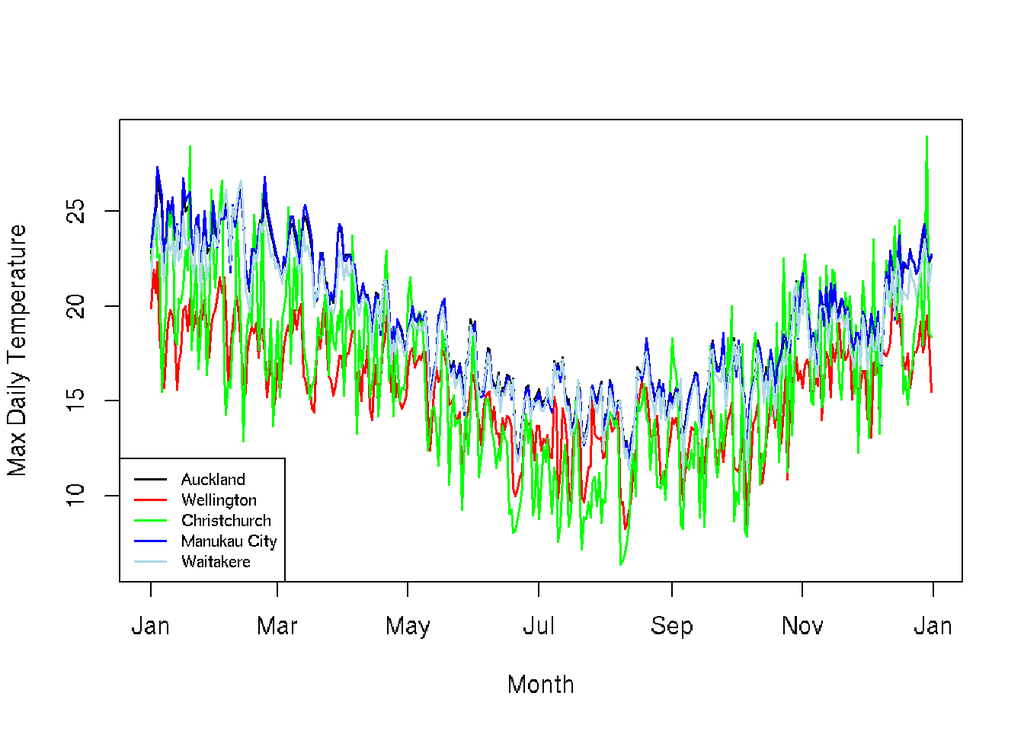

```r
# top 5 cities
top_cities <- cities[order(-cities$population),][1:5,]

# date range
start_date <- "2022-01-01"
end_date <- "2022-12-31"

temp_data <- data.frame()

# url format
# https://archive-api.open-meteo.com/v1/archive?latitude=52.52&longitude=13.41&start_date=2022-01-01&end_date=2022-12-31&daily=temperature_2m_max&timezone=Pacific%2FAuckland

# fetch data by urls
for (i in 1:5) {
  city <- top_cities$city[i]
  lat <- top_cities$lat[i]
  lng <- top_cities$lng[i]

  # create URL
  url <- paste0("https://archive-api.open-meteo.com/v1/archive?",
                "latitude=", lat,
                "&longitude=", lng,
                "&start_date=", start_date,
                "&end_date=", end_date,
                "&daily=temperature_2m_max",
                "&timezone=Pacific/Auckland")

  # get data set
  data <- jsonlite::fromJSON(url)

  # extract date and temp
  top_cities_tmp <- data.frame(
    date = as.Date(data$daily$time),
    temp = data$daily$temperature_2m_max,
    city = city
  )
  # bind data
  temp_data <- rbind(temp_data, top_cities_tmp)
}

# plot canvas
# use xaxt to diminish default x label
plot(NA, NA, xlim = c(as.Date(start_date), as.Date(end_date)), ylim = range(temp_data$temp), xlab = "Month", ylab = "Max Daily Temperature", type = "n", xaxt = "n")

# self-defined x label: month
axis.Date(1, at = seq(as.Date(start_date), as.Date(end_date)+31, by = "2 months"), format = "%b")
# colors as cities
colors <- c("black", "red", "green", "blue", "light blue")

# lines
for (i in 1:5) {
  city_data <- temp_data[temp_data$city == top_cities$city[i],]
  lines(city_data$date, city_data$temp, col = colors[i], lwd = 1.7)
}

legend("bottomleft", legend = top_cities$city, col = colors, lty = 1, lwd = 1.7, cex = 0.7)
```

Comment on the plot. Overall, this graph provides an intuitive perspective on the temperature trends of the five main cities in New Zealand.

# Summary

This report analyzes the temperature data of major cities in New Zealand using OpenMeteo.com API. Through this analysis, we aim to understand the historical trends and annual variations in temperatures.

Data Acquisition and Processing: We downloaded the daily minimum and maximum temperature data for Auckland from 01/01/1980, to 30/06/2023, using the OpenMeteo API. We obtained tabular data for all major cities in New Zealand and extracted the coordinates of the five most populous cities.

Data Analysis and Modeling: We checked the integrity and reasonableness of the temperature data for Auckland. We calculated the average daily temperature for each year by computing the mean of the daily minimum and maximum temperatures. We fitted two models using the data from 1980 to 2014 as the training set: a simple overall mean model and a linear regression model with the year as a predictive variable. We analyzed the RMSE of these models and performed polynomial models to obtain more accurate predictions.

Visual Analysis: We extracted the highest daily temperatures for the five most populous cities in New Zealand in the year 2022 and visualized the results as a line graph using R’s native graphics functions. This graph displayed the temperature differences and seasonal variations among these cities throughout the year.